# 자연언어처리 11주차_기계학습을 사용한 자연언어처리 #3: 지도학습 - 회귀

고려대학교 일반대학원 심리학과

2022년 11월 14일 월요일 6-7교시

# 1. 지도학습 I: 선형회귀(linear regression)

## (1) 준비사항

```r
# 모형수립 과정에 사용되는 주요 패키지.
library(tidyverse) # 데이터 조작 및 시각화용.
library(tidymodels) # 데이터 전처리 및 모형 훈련용.
library(caret) # 모형 훈련용.
library(broom) # 분석결과를 tidy 데이터프레임 형식으로 제시.
library(vip) #변수 중요도 해석용.
library(pdp) #변수 중요도 해석용.
library(mixOmics) # step_pls() 수행용.
# 시범용 데이터셋.
library(AmesHousing)
ames <- AmesHousing::make_ames() %>% # Iowa주 Ames의 2,930개 부동산 물건에 대한 정보를 담고 있음.
  as_tibble()

# ames 데이터셋을 훈련용과 검증용으로 나누기.
set.seed(123) # 재현 가능성을 위해 난수 고정.
split <- initial_split(ames, prop = 0.7)
ames_train <- training(split)
ames_test <- testing(split)
```

## (2) 단순선형회귀(simple linear regression)

- 정의: 하나의 등간척도 결과변수와 하나의 등간척도 예측변수 간의 선형적 관계의 강도를 통계적으로 나타내는 알고리즘.
- 공식
  - $Y_i = \beta_0 + \beta_1 X_i + \epsilon_i, \quad i = 1, 2, \dots, n$
  - 설명: $Y_i$ $\Rightarrow$ *i*번째 결과변수 값, $X_i$ $\Rightarrow$ *i*번째 예측변수 값, $\beta_0$ $\Rightarrow$ 회귀선의 절편, $\beta_1$ $\Rightarrow$ 회귀선의 기울기, $\epsilon_i$ $\Rightarrow$ 잡음 또는 무선오차. 해당 오차는 정규분포를 이루고 있는 것으로 가정됨.
- 모형 1: 주택가격(`Sale_Price`)을 지하를 제외한 총 실평수(`Gr_Liv_Area`)로 예측.

```r
# R 내장함수인 lm으로 모형 생성: 예측변수 Gr_Liv_Area 투입.
model1 <- lm(Sale_Price ~ Gr_Liv_Area, data = ames_train)
summary(model1)
```

```
##
## Call:
## lm(formula = Sale_Price ~ Gr_Liv_Area, data = ames_train)
##
## Residuals:
##     Min      1Q  Median      3Q     Max
## -478762  -30030   -1405   22273  335855
##
## Coefficients:
##              Estimate Std. Error t value Pr(>|t|)
## (Intercept) 14045.872   3942.503   3.563 0.000375 ***
## Gr_Liv_Area   110.726      2.506  44.185  < 2e-16 ***
## ---
## Signif. codes:  0 '***' 0.001 '**' 0.01 '*' 0.05 '.' 0.1 ' ' 1
##
## Residual standard error: 57430 on 2049 degrees of freedom
## Multiple R-squared:  0.4879, Adjusted R-squared:  0.4877
## F-statistic:  1952 on 1 and 2049 DF,  p-value: < 2.2e-16
```

## (3) 다중선형회귀(multiple linear regression)

### 1) 예측변수를 2개 투입하는 경우

- 정의: 하나의 등간척도 결과변수와 여러 개의 등간척도 예측변수 간의 선형적 관계의 강도를 통계적으로 나타내는 알고리즘.
- 공식
  - $Y = \beta_0 + \beta_1 X_1 + \beta_2 X_2 + \epsilon$
  - $X_1$ & $X_2$ $\Rightarrow$ 첫 번째 & 두 번째 예측변수의 값.
- 모형 2: 주택가격(`Sale_Price`)을 지하를 제외한 총 실평수(`Gr_Liv_Area`)와 건축연도(`Year_Built`)로 예측.

```r
# R 내장함수인 lm으로 모형 생성: 예측변수 Gr_Liv_Area 및 Year_Built 투입.
model2 <- lm(Sale_Price ~ Gr_Liv_Area + Year_Built, data = ames_train)
model2 <- update(model1, . ~ . + Year_Built) # update 함수를 사용하여 model1 함수에 새로운 변수를 추가.
summary(model2)
```

```
##
## Call:
## lm(formula = Sale_Price ~ Gr_Liv_Area + Year_Built, data = ames_train)
##
## Residuals:
##     Min      1Q  Median      3Q     Max
## -451739  -26970   -2970   18328  308123
##
## Coefficients:
##               Estimate Std. Error t value Pr(>|t|)
## (Intercept) -2.157e+06  6.923e+04  -31.16   <2e-16 ***
## Gr_Liv_Area  9.436e+01  2.124e+00   44.41   <2e-16 ***
## Year_Built   1.114e+03  3.548e+01   31.40   <2e-16 ***
## ---
## Signif. codes:  0 '***' 0.001 '**' 0.01 '*' 0.05 '.' 0.1 ' ' 1
##
## Residual standard error: 47200 on 2048 degrees of freedom
## Multiple R-squared:  0.6543, Adjusted R-squared:  0.654
## F-statistic:  1938 on 2 and 2048 DF,  p-value: < 2.2e-16
```

### 2) 모든 예측변수를 투입하는 경우

- 공식
  - $Y = \beta_0 + \beta_1 X_1 + \beta_2 X_2 + \cdots + \beta_p X_p + \epsilon$
  - $X_i, \quad i = 1, 2, \dots, p$ $\Rightarrow$ *i*번째 예측변수 값. 상기 예측변수 중 일부는 상호작용(예를 들면, $X_3 = X_1 \times X_2$)를 나타낼 수도 있음.

```r
# R 내장함수인 lm으로 모형 생성: 모든 예측변수 투입.
model3 <- lm(Sale_Price ~ ., data = ames_train)
tidy(model3) # broom 패키지의 tidy 함수를 사용하여 주요 통계분석 결과를 tidy 데이터프레임 형식으로 제시.
```

```
## # A tibble: 303 × 5
##    term                                          estim…¹ std.e…² stati…³ p.value
##    <chr>                                           <dbl>   <dbl>   <dbl>   <dbl>
##  1 (Intercept)                                   636880.  1.04e7  0.0611   0.951
##  2 MS_SubClassOne_Story_1945_and_Older             3433.  3.29e3  1.05     0.296
##  3 MS_SubClassOne_Story_with_Finished_Attic_All…   -500.  1.25e4 -0.0400   0.968
##  4 MS_SubClassOne_and_Half_Story_Unfinished_All…  -1179.  1.28e4 -0.0922   0.927
##  5 MS_SubClassOne_and_Half_Story_Finished_All_A…   2837.  5.81e3  0.488    0.626
##  6 MS_SubClassTwo_Story_1946_and_Newer             1255.  5.21e3  0.241    0.810
##  7 MS_SubClassTwo_Story_1945_and_Older             7923.  5.92e3  1.34     0.181
##  8 MS_SubClassTwo_and_Half_Story_All_Ages         -5875.  1.23e4 -0.476    0.634
##  9 MS_SubClassSplit_or_Multilevel                -12813.  1.25e4 -1.02     0.306
## 10 MS_SubClassSplit_Foyer                         -1671.  6.94e3 -0.241    0.810
## # … with 293 more rows, and abbreviated variable names ¹estimate, ²std.error,
## #   ³statistic
```

## (4) 모형의 정확도 평가

- `lm` 함수로는 상술한 3가지 모형 중 어느 것이 가장 나은지 알기 어려움.
- 모형평가 방법: RMSE, 재표집(예를 들면, 교차 타당도 확인) 등을 통해 모형의 질을 평가할 수 있음.
- **caret** 패키지의 장점: 모형의 정확도를 평가할 수 있는 다양한 내장기능 포함.
- 전처리 청사진 수립 후 모형 생성하는 경우:

```r
# tidymodels 패키지로 데이터 전처리하기.
blueprint1 <- recipe(Sale_Price ~ Gr_Liv_Area, data = ames_train) %>%
  step_log(all_outcomes()) %>%
  step_normalize(all_numeric_predictors())

# 재표집 전략 규정하기.
cv_method <- trainControl(
  method = "cv",
  number = 10)

# caret 패키지로 모형 생성하기: model1 CV.
set.seed(123) # 재현 가능성을 위해 난수 고정하기.
cv_model1_b <- train(
  blueprint1, # tidymodels의 전처리 청사진 사용.
  data = ames_train, # ames_train 데이터셋 사용.
  method = "lm", # 선형회귀모형 사용.
  trControl = cv_method) # 재표집 전략.
cv_model1_b
```

```
## Linear Regression
##
## 2051 samples
##   80 predictor
##
## Recipe steps: log, normalize
## Resampling: Cross-Validated (10 fold)
## Summary of sample sizes: 1845, 1847, 1845, 1846, 1846, 1847, ...
## Resampling results:
##
##   RMSE       Rsquared  MAE
##   0.2990339  0.48038   0.2174287
##
## Tuning parameter 'intercept' was held constant at a value of TRUE
```

```r
# tidymodels 패키지로 데이터 전처리하기.
blueprint2 <- recipe(Sale_Price ~ Gr_Liv_Area + Year_Built, data = ames_train) %>%
  step_log(all_outcomes()) %>%
  step_normalize(all_numeric_predictors())

# caret 패키지로 모형 생성하기: model2 CV
set.seed(123)
cv_model2_b <- train(
  blueprint2,
  data = ames_train,
  method = "lm",
  trControl = cv_method)
cv_model2_b
```

```
## Linear Regression
##
## 2051 samples
##   80 predictor
##
## Recipe steps: log, normalize
## Resampling: Cross-Validated (10 fold)
## Summary of sample sizes: 1845, 1847, 1845, 1846, 1846, 1847, ...
## Resampling results:
##
##   RMSE       Rsquared   MAE
##   0.2270481  0.7003745  0.1607428
##
## Tuning parameter 'intercept' was held constant at a value of TRUE
```

```r
# tidymodels 패키지로 데이터 전처리하기.
blueprint3 <- recipe(Sale_Price ~ ., data = ames_train) %>%
  step_log(all_outcomes()) %>%
  step_normalize(all_numeric_predictors())

# caret 패키지로 모형 생성하기: model3 CV
set.seed(321)
cv_model3_b <- train(
  blueprint3,
  data = ames_train,
  method = "lm",
  trControl = cv_method)
cv_model3_b
```

```
## Linear Regression
##
## 2051 samples
##   80 predictor
##
## Recipe steps: log, normalize
## Resampling: Cross-Validated (10 fold)
## Summary of sample sizes: 1844, 1844, 1847, 1847, 1845, 1845, ...
## Resampling results:
##
##   RMSE       Rsquared   MAE
##   0.1045967  0.9233281  0.07632797
##
## Tuning parameter 'intercept' was held constant at a value of TRUE
```

- 전처리 청사진 수립하지 않고 모형 생성하는 경우:

```r
# 재표집 전략 규정하기.
cv_method <- trainControl(
  method = "cv",
  number = 10)

# caret 패키지로 모형 생성하기: model1 CV.
set.seed(123) # 재현 가능성을 위해 난수 고정하기.
cv_model1 <- train(
  form = Sale_Price ~ Gr_Liv_Area, # 예측모형 투입.
  data = ames_train, # ames_train 데이터셋 사용.
  method = "lm", # 선형회귀모형 사용.
  trControl = cv_method) # 재표집 전략.
cv_model1
```

```
## Linear Regression
##
## 2051 samples
##    1 predictor
##
## No pre-processing
## Resampling: Cross-Validated (10 fold)
## Summary of sample sizes: 1845, 1847, 1845, 1846, 1846, 1847, ...
## Resampling results:
##
##   RMSE      Rsquared   MAE
##   57405.61  0.4966773  38705.1
##
## Tuning parameter 'intercept' was held constant at a value of TRUE
```

```r
# caret 패키지로 모형 생성하기: model2 CV
set.seed(123)
cv_model2 <- train(
  Sale_Price ~ Gr_Liv_Area + Year_Built,
  data = ames_train,
  method = "lm",
  trControl =cv_method)
cv_model2
```

```
## Linear Regression
##
## 2051 samples
##    2 predictor
##
## No pre-processing
## Resampling: Cross-Validated (10 fold)
## Summary of sample sizes: 1845, 1847, 1845, 1846, 1846, 1847, ...
## Resampling results:
##
##   RMSE      Rsquared   MAE
##   47079.41  0.6644809  31608.69
##
## Tuning parameter 'intercept' was held constant at a value of TRUE
```

```r
# caret 패키지로 모형 생성하기: model3 CV
set.seed(123)
cv_model3 <- train(
  Sale_Price ~ .,
  data = ames_train,
  method = "lm",
  trControl = cv_method)
cv_model3
```

```
## Linear Regression
##
## 2051 samples
##   80 predictor
##
## No pre-processing
## Resampling: Cross-Validated (10 fold)
## Summary of sample sizes: 1845, 1847, 1845, 1846, 1846, 1847, ...
## Resampling results:
##
##   RMSE      Rsquared   MAE
##   36090.24  0.8077398  17045.64
##
## Tuning parameter 'intercept' was held constant at a value of TRUE
```

```r
# 세 모형 간 교차 타당도 비교.
resamples(list(model1 = cv_model1,
               model2 = cv_model2,
               model3 = cv_model3)) %>%
  summary()
```

```
##
## Call:
## summary.resamples(object = .)
##
## Models: model1, model2, model3
## Number of resamples: 10
##
## MAE
##            Min.  1st Qu.   Median     Mean  3rd Qu.     Max. NA's
## model1 35828.97 36718.04 38534.75 38705.10 40189.44 42255.08    0
## model2 27935.72 29450.12 30975.14 31608.69 33790.64 36694.14    0
## model3 14063.82 14953.40 16169.32 17045.64 18703.02 22243.20    0
##
## RMSE
##            Min.  1st Qu.   Median     Mean  3rd Qu.     Max. NA's
## model1 50040.92 51580.48 55746.62 57405.61 63211.65 68184.52    0
## model2 38383.16 42220.60 44848.37 47079.41 52009.79 58502.10    0
## model3 19649.83 20779.15 26767.96 36090.24 47813.82 70745.75    0
##
## Rsquared
##             Min.   1st Qu.    Median      Mean   3rd Qu.      Max. NA's
## model1 0.3142557 0.4949973 0.5183583 0.4966773 0.5504685 0.5801282    0
## model2 0.4893800 0.6587995 0.6781786 0.6644809 0.6993082 0.7179889    0
## model3 0.4739520 0.7154205 0.9075988 0.8077398 0.9225830 0.9404901    0
```

## (5) 모형의 가정 충족 여부 확인

### 1) 선형적 관계

- 가정: 선형회귀는 예측변수와 결과변수 간 선형적 관계를 전제로 함.
- 가정위반 시 해결책: 비선형적 관계도 예측/결과변수 자료변형을 통해 선형적 관계로 만들 수 있음.

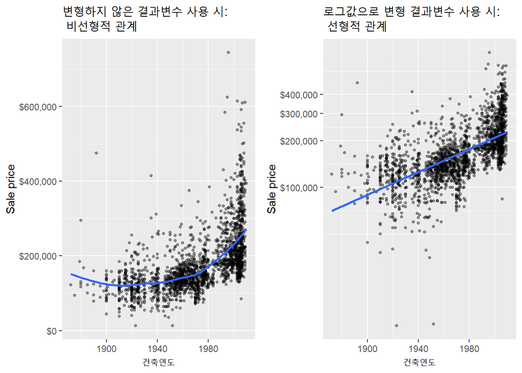

```r
# 주택가격과 건축연도 간 관계 시각화: 결과변수 Sale_Price를 그대로 사용했을 경우.
p1 <- ggplot(ames_train, aes(Year_Built, Sale_Price)) +
  geom_point(size = 1, alpha = .4) +
  geom_smooth(se = FALSE) +
  scale_y_continuous("Sale price", labels = scales::dollar) + # y축(주택가격)을 그대로 사용한 경우.
  xlab("건축연도") +
  ylab("주택가격") +
  ggtitle(paste("변형하지 않은 결과변수 사용 시:\n",
                "비선형적 관계"))

# 주택가격과 건축연도 간 관계 시각화: 결과변수 Sale_Price를 로그값으로 변형했을 경우.
p2 <- ggplot(ames_train, aes(Year_Built, Sale_Price)) +
  geom_point(size = 1, alpha = .4) +
  geom_smooth(method = "lm", se = FALSE) +
  scale_y_log10("Sale price", labels = scales::dollar, # y축(주택가격)을 로그화한 경우.
                breaks = seq(0, 400000, by = 100000)) +
  xlab("건축연도") +
  ylab("주택가격") +
  ggtitle(paste("로그값으로 변형 결과변수 사용 시:\n",
                "선형적 관계"))

# 두 개의 플롯을 나란히 배치.
library(gridExtra)
grid.arrange(p1, p2, nrow = 1)
```

### 2) 잔차(오차)의 분산이 일정할 것

- 잔차의 등분산성(Homoscedasticity)
  - 선형회귀에서 오차항($\epsilon_1, \epsilon_2, \dots, \epsilon_p$)의 분산은 항상 일정해야 함. 즉 잔차의 분산이 일정한 상수임을 가정하는 것.
  - 오차분산이 일정한 상수를 나타내지 않는다면, $\beta$ 계수의 신뢰구간과 *p* 값의 타당도가 위협받게 됨.
- 가정위반 시 해결책
  - 예측/결과변수 자료변형.
  - 새로운 예측변수 추가.
- **broom** 패키지의 `augment` 함수: 모형결과(예를 들면, 예측값, 잔차 등)를 기존 데이터셋의 각 관찰값에 별도의 열로 추가해줌.

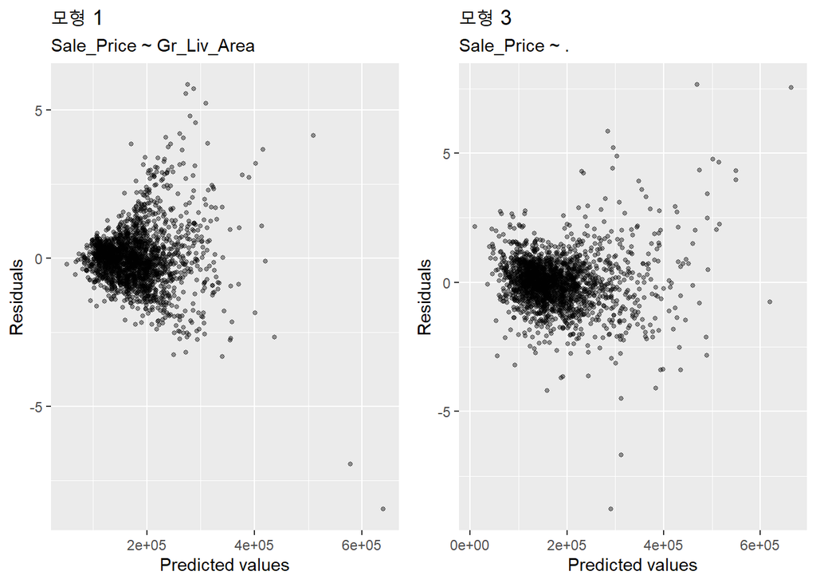

```r
# 모형 1의 결과(예를 들면, 예측값, 잔차 등)를 기존 데이터셋에 별도의 열로 추가하기.
df1 <- augment(cv_model1$finalModel, data = ames_train)

# 모형 1의 잔차분산 시각화하기.
p1 <- ggplot(df1, aes(x=.fitted, y=.std.resid)) + # x축에 예측값, y축에 잔차를 넣기.
  geom_point(size = 1, alpha = .4) +
  xlab("Predicted values") +
  ylab("Residuals") +
  ggtitle("모형 1", subtitle = "Sale_Price ~ Gr_Liv_Area")

# 모형 3의 결과(예를 들면, 예측값, 잔차 등)를 기존 데이터셋에 별도의 열로 추가하기.
df2 <- augment(cv_model3$finalModel, data = ames_train)

# 모형 3의 잔차분산 시각화하기.
p2 <- ggplot(df2, aes(x=.fitted, y=.std.resid)) + # x축에 예측값, y축에 잔차를 넣기.
  geom_point(size = 1, alpha = .4)  +
  xlab("Predicted values") +
  ylab("Residuals") +
  ggtitle("모형 3", subtitle = "Sale_Price ~ .")

# 두 개의 플롯을 나란히 배치.
gridExtra::grid.arrange(p1, p2, nrow = 1)
```

- 결과해석: 새로운 예측변수들이 대거 추가된 모형 3은 비교적 잔차의 분산이 일정한 분포를 나타냄.

### 3) 오차 간 독립성

- 자기상관(autocorrelation)
  - 선형회귀에서 오차항들은 서로 독립적이고 상관이 없어야 함. 일련의 연속된 관찰값들이 상관을 나타낼 때 일어남. [EX] 한 시점의 행태가 다음 시점의 행태와 밀접한 관련이 있는 경우.
  - 가령 오차항 $\epsilon_1$과 $\epsilon_2$ 간에 상관이 존재한다면, $\beta$ 계수의 추정오차에 편향을 가져옴.
- 자기상관의 원인: `Ames` 데이터셋은 관찰값이 동네(`neighborhood`)순으로 나열되어 있음. $\rightarrow$ 그런데 모형 1에선 `neighborhood` 변수가 포함되어 있지 않음. $\rightarrow$ 그 결과, 같은 동네의 예측오차끼리 상관을 이루게 됨. 왜냐면 같은 동네의 주택들은 크기가 비슷할 확률이 높기 때문.
- 가정위반 시 해결책: 자기상관을 야기하는 변수를 모형에 포함하기.

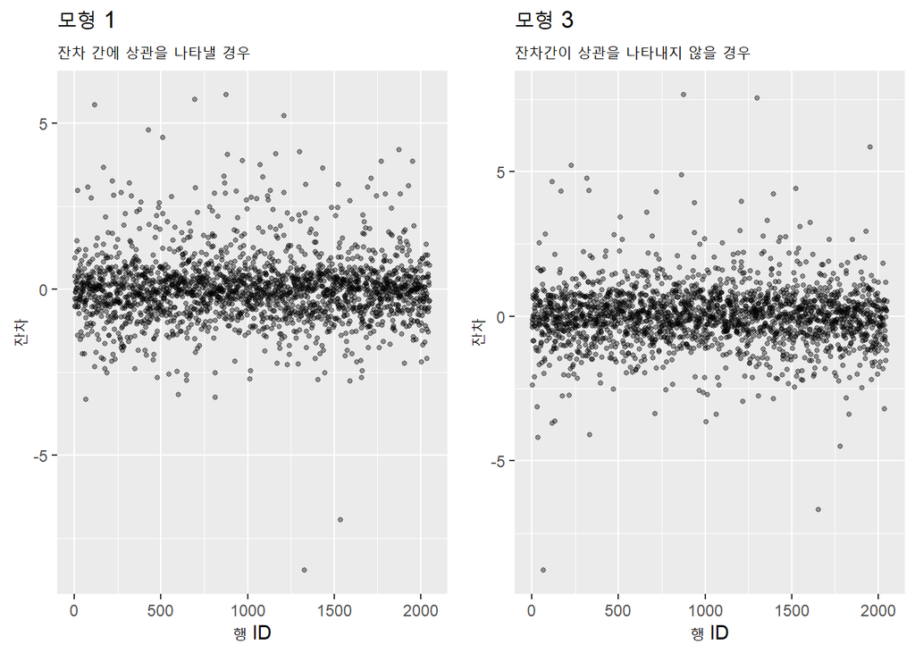

```r
# 행 번호로 구성된 id라는 새로운 열 추가.
df1 <- df1 %>%
  mutate(id = row_number())
df2 <- df2 %>%
  mutate(id = row_number())

# 모형 1: 잔차 간에 상관을 나타낼 경우.
p1 <- ggplot(df1, aes(x=id, y=.std.resid)) +
  geom_point(size = 1, alpha = .4) +
  xlab("행 ID") +
  ylab("잔차") +
  ggtitle("모형 1", subtitle = "잔차 간에 상관을 나타낼 경우")

# 모형 3: 잔차 간에 상관을 나타내지 않을 경우.
p2 <- ggplot(df2, aes(x=id, y=.std.resid)) +
  geom_point(size = 1, alpha = .4) +
  xlab("행 ID") +
  ylab("잔차") +
  ggtitle("모형 3", subtitle = "잔차간이 상관을 나타내지 않을 경우")

# 두 개의 플롯을 나란히 배치.
gridExtra::grid.arrange(p1, p2, nrow = 1)
```

### 5) 다중공선성(multicollinearity)이 없을 것

```r
# 강한 상관을 지닌 두 예측변수의 회귀계수 및 통계적 유의성 확인하기.
cv_model3 %>%
  summary() %>% # 모형 적합도 통계분석 결과 제시.
  tidy() %>% # broom 패키지의 tidy 함수를 사용하여 tidy 형식으로 결과 제시.
  filter(term %in% c("Garage_Area", "Garage_Cars")) # 예측변수 중 Garage_Cars와 Garage_Area 분석결과만 제시하기.
```

```
## # A tibble: 2 × 5
##   term        estimate std.error statistic p.value
##   <chr>          <dbl>     <dbl>     <dbl>   <dbl>
## 1 Garage_Cars   2749.    1625.        1.69 0.0909
## 2 Garage_Area     15.1      5.41      2.79 0.00539
```

- 가정위반 시 해결책
  - 직접제거
    - 방법: 상관의 수준이 미리 설정한 분기점 이하가 될 때까지 강한 상관을 지닌 예측변수들을 한 번에 하나씩 직접 제거하기.
    - 한계: 특정 예측변수와 강한 상관을 이루는 예측변수의 수가 많을 경우, 직접제거 방법은 현실적이지 못함.
  - 차원축소: 선형회귀 수행 전에 차원을 축소하는 방법.

```r
# Garage_Cars 변수 제거한 모형 생성하기.
set.seed(123)
mod_wo_Garage_Cars <- train(
  Sale_Price ~ .,
  data = dplyr::select(ames_train, -Garage_Cars), # ames_train 데이터에서 Garage_Cars 열 제거하기.
  method = "lm",
  trControl = trainControl(method = "cv", number = 10)
)

# 강한 상관을 지닌 두 예측변수 중 하나를 제거한 뒤 회귀계수 및 통계적 유의성 확인하기.
mod_wo_Garage_Cars %>%
  summary() %>% # 모형 적합도 통계분석 결과 제시.
  tidy() %>% # broom 패키지의 tidy 함수를 사용하여 tidy 형식으로 결과 제시.
  filter(term == "Garage_Area") # 예측변수 중 Garage_Area 분석결과만 제시하기.
```

```
## # A tibble: 1 × 5
##   term        estimate std.error statistic      p.value
##   <chr>          <dbl>     <dbl>     <dbl>        <dbl>
## 1 Garage_Area     21.6      3.79      5.71 0.0000000131
```

## (6) 주성분 회귀(principal component regression, PCR)

- 주성분 회귀 절차
  - 1단계: 주성분 분석(principal components analysis) 시행. $\Rightarrow$ 상관을 지닌 변수들을 상관이 없는 소수의 변수들(주성분)로 묶어내는 방법.
  - 2단계: 분석을 통해 얻은 주성분을 선형회귀 모형에 예측변수로 투입.

- 함수: **caret** 패키지의 `train()`
  - 논항 1: `method = "pcr"`.
  - 논항 2: `tuneLength = k` $\Rightarrow$ 평가대상이 되는 초매개변수 조합의 개수. 여기선 초매개변수가 “주성분의 수” 하나이므로, *k* = 100이라면 예측변수로 사용할 주성분의 수를 1-100개로 설정한 셈이 됨.
- **tidymodels** 패키지로 주성분 회귀 수행하기:

```r
# tidymodels 패키지로 전처리하기.
blueprint <- recipe(Sale_Price ~ ., data = ames_train) %>%
  step_zv(all_predictors()) %>% # 영분산 변수 제거.
  step_nzv(all_predictors()) %>% # 영분산 근접 변수 제거.
  step_normalize(all_numeric(), -all_outcomes()) %>% # 등간척도 예측변수 표준화하기.
  step_pca(all_numeric_predictors(), threshold = .95) # step_pca() 함수로 차원축소하기.

# 재표집 및 완전탐색 전략 수립하기.
fitControl <- trainControl(method = "cv",
                           number = 10)

# tidymodels 전처리 청사진을 이용하여 모형 수립하기.
set.seed(123)
cv_model_pcr_bp <- train(
  blueprint, # 차원축소를 마친 전처리 청사진 투입하기.
  data = ames_train,
  method = "lm", # 선형회귀분석 시행하기.
  trControl = fitControl,
  tuneLength = 100 # 주성분의 수를 1-100개로 설정.
  )
```

- **caret** 패키지로 주성분 회귀 수행하기:

```r
# 재표집 및 완전탐색 전략 수립하기.
fitControl <- trainControl(method = "cv",
                           number = 10)

# caret 패키지로 전처리하여 모형 수립하기.
set.seed(123)
cv_model_pcr <- train(
  Sale_Price ~ .,
  data = ames_train,
  method = "pcr",
  trControl = fitControl,
  preProcess = c("zv", "center", "scale"), # 영분산 변수 제거, 등간척도 변수 표준화하기.
  tuneLength = 100
  )

# 가장 낮은 RMSE를 지닌 모형의 주성분 수.
cv_model_pcr$bestTune
```

```
##     ncomp
## 100   100
```

```r
# 가장 낮은 RMSE를 지닌 모형의 결과값.
cv_model_pcr$results %>%
  filter(ncomp == pull(cv_model_pcr$bestTune))
```

```
##   ncomp     RMSE  Rsquared      MAE  RMSESD RsquaredSD    MAESD
## 1   100 32106.28 0.8412169 20385.16 9753.04 0.08588015 2297.757
```

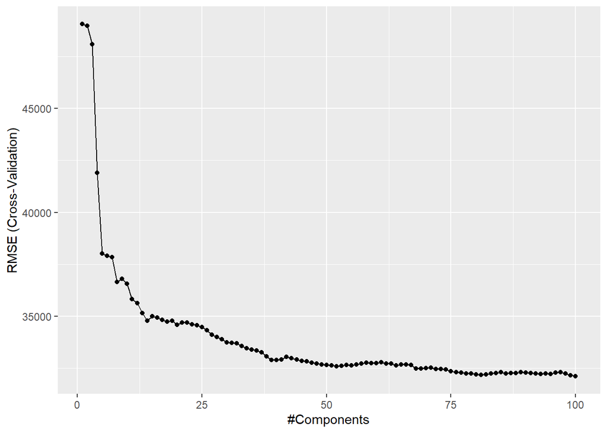

```r
# 교차 타당도 확인을 거친 RMSE 시각화하기.
ggplot(cv_model_pcr)
```

- 결과해석
  - 주성분의 수가 5개만 되어도 예측오차가 급격히 떨어지는 것을 볼 수 있음.
  - 그러나 최소 RMSE에 도달하려면 거의 100개에 달하는 주성분이 필요함.
- 한계점
  - 주성분 회귀는 성분을 선택할 때 결과변수를 고려하지 않음. 따라서 주성분 분석을 통해 생성된 새로운 예측변수들은 결과변수와의 관계를 극대화하도록 설계되어 있지 않음.
  - 주성분들과 결과변수 간의 관계를 제대로 포착하지 못함에 따라 예측의 정확도가 떨어질 가능성이 있음.

## (7) 부분 최소 제곱(partial least squares, PLS)

- 설명
  - 차원축소 방법의 지도학습 버전으로 볼 수 있음.
  - 주성분 회귀와의 비교
    - 공통점: 변수들의 선형적 조합을 생성.
    - 차이점: 주성분 구성 시 결과변수를 고려함.
    - 의의: 원 예측변수들의 정보들을 담아내는 것은 물론, 결과변수와 밀접한 관계를 지닌 새로운 성분들을 찾아냄!

- [그림 3] 해석: 주성분 회귀의 첫 두 주성분은 결과변수와 거의 상관이 없음. 그러나 부분 최소 제곱의 첫 두 성분은 결과변수와 상당한 상관을 나타냄.

**[그림 3] 주성분 회귀 및 부분 최소 제곱 회귀의 첫 두 성분과 결과변수 간 관계 비교**

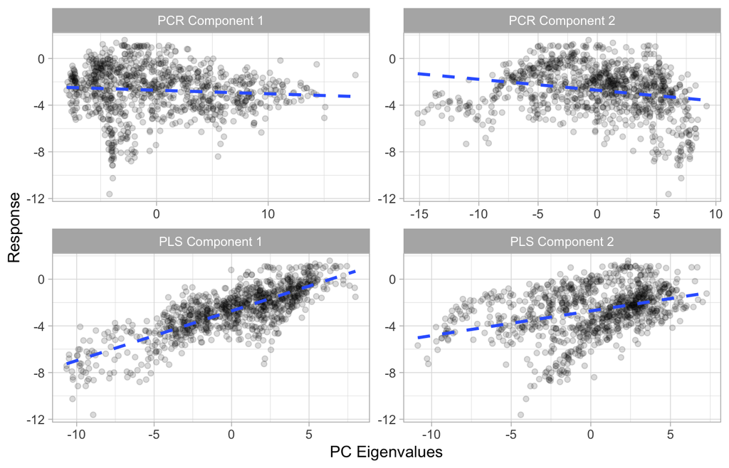

- 함수: **caret** 패키지의 `train()`
  - 논항 1: `method = "pls"`.
  - 논항 2: `tuneLength = k` $\Rightarrow$ 평가대상이 되는 초매개변수 조합의 개수. 여기선 초매개변수가 “주성분의 수” 하나이므로, *k* = 30이라면 예측변수로 사용할 주성분의 수를 1-30개로 설정한 셈이 됨.

```r
# tidymodels 패키지로 전처리하기.
blueprint <- recipe(Sale_Price ~ ., data = ames_train) %>%
  step_zv(all_predictors()) %>% # 영분산 변수 제거.
  step_nzv(all_predictors()) %>% # 영분산 근접 변수 제거.
  step_normalize(all_numeric_predictors()) %>% # 등간척도 예측변수 표준화하기.
  step_pls(all_numeric_predictors(), outcome = "Sale_Price", num_comp = 4) # step_pls() 함수로 차원축소하기.

# 재표집 및 완전탐색 전략 수립하기.
fitControl <- trainControl(method = "cv",
                           number = 10)

# tidymodels 전처리 청사진을 이용하여 모형 수립하기.
set.seed(123)
cv_model_pls_bp <- train(
  blueprint, # 차원축소를 마친 전처리 청사진 투입하기.
  data = ames_train,
  method = "lm", # 선형회귀분석 시행하기.
  trControl = fitControl,
  tuneLength = 30 # 주성분 개수 범위를 1-30개로 설정.
  )

# caret 패키지로 전처리하여 모형 수립하기.
set.seed(123)
cv_model_pls <- train(
  Sale_Price ~ .,
  data = ames_train,
  method = "pls",
  trControl = fitControl,
  preProcess = c("zv", "center", "scale"), # 영분산 변수 제거, 등간척도 변수 표준화하기.
  tuneLength = 30
  )

# 가장 낮은 RMSE를 지닌 모형의 주성분 수.
cv_model_pls$bestTune
```

```
##    ncomp
## 10    10
```

```r
# 가장 낮은 RMSE를 지닌 모형의 결과값.
cv_model_pls$results %>%
  filter(ncomp == pull(cv_model_pls$bestTune))
```

```
##   ncomp     RMSE  Rsquared      MAE   RMSESD RsquaredSD    MAESD
## 1    10 30402.87 0.8546502 17537.71 14090.22  0.1262143 2326.537
```

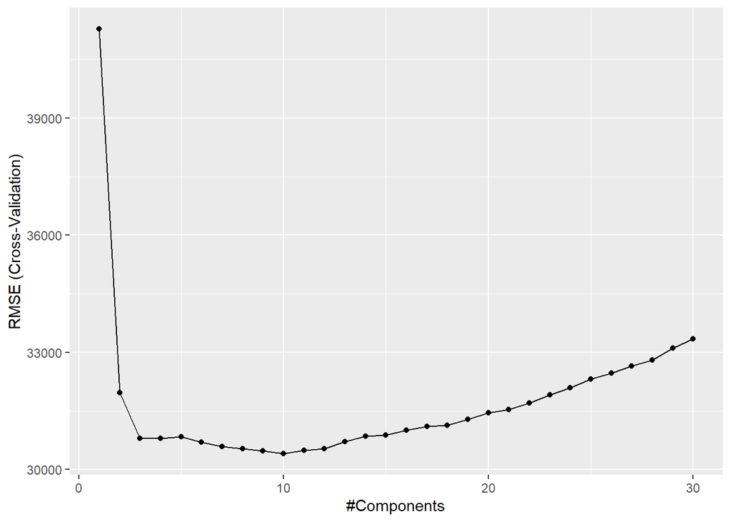

```r
# 교차 타당도 확인을 거친 RMSE 시각화하기.
ggplot(cv_model_pls)
```

## (8) 예측변수 해석

- 선형회귀모형은 예측변수와 결과변수 간의 단선적 선형관계를 가정하기에 매우 직관적.
- 선형회귀모형에서 변수의 영향력을 측정하는 방법
  - 모형 매개변수들의 *t*-검정값 확인. 그러나 상호작용 효과가 포함되거나 복잡한 자료변형이 병행되는 경우 해석이 어려움.
  - 부분 최소 제곱 모형에서는 잔차 제곱합(residual sum of squares, RSS)을 줄이는 데 기여도가 높을수록 모형의 중요도 또한 높아짐.

### 1) **vip** 패키지의 `vip()` 함수를 사용하는 경우

- **vip** 패키지의 `vip()` 함수
  - 논항 1: 모형 객체.
  - 논항 2: `num_features` $\Rightarrow$ 중요도 상위 변수의 개수.
  - 논항 3: `method` $\Rightarrow$ 변수의 중요도 유형. 기본값은 `model`임. 모형 기반 변수 중요도 점수 계산 시 사용.

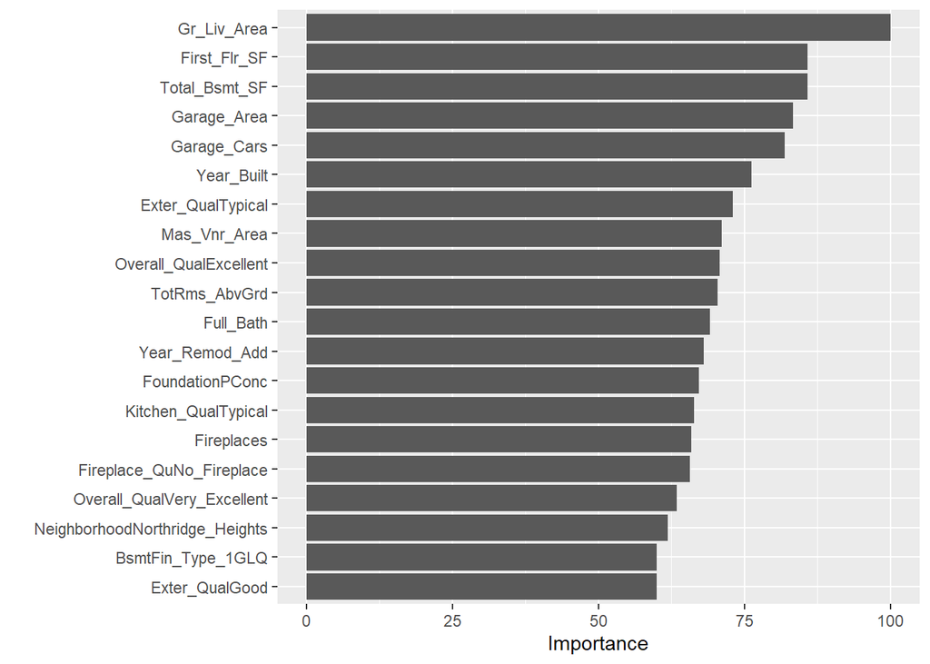

```r
# vip 패키지의 vip() 함수를 사용하여 해당 모형에 속한 상위 20개 변수들의 중요도 계산하기.
vip::vip(cv_model_pls, num_features = 20, method = "model")
```

### 2) **pdp** 패키지의 `partial()` 함수를 사용하는 경우

- 부분 독립 플롯(partial dependence plots, PDPs)
  - 역할: 특정 예측변수에 따라 평균 예측값($\widehat{y}$)이 어떻게 변화하는지를 시각화해줌.
  - 장점: 모형의 모든 다른 예측변수들의 평균효과를 고려하여 둘의 관계를 나타내줌!
- **pdp** 패키지의 `partial()` 함수
  - 논항 1: 모형 객체.
  - 논항 2: 예측변수.
  - 논항 3: `plot = TRUE`.
- [그림 4] 해석: 가장 중요도가 높은 네 변수의 부분 독립 플롯을 보면, 중요한 변수일수록 기울기($\widehat{\beta}_i$)가 가파른 것을 알 수 있음.

```r
# 가장 중요한 네 변수의 부분 독립 플롯.
Gr_Liv_Area.pdp <- partial(cv_model_pls, "Gr_Liv_Area", plot = TRUE) # 지하공간을 제외한 생활공간의 제곱피트.
Total_Bsmt_SF.pdp <- partial(cv_model_pls, "Total_Bsmt_SF", plot = TRUE) # 지하공간의 총 제곱피트.
First_Flr_SF.pdp <- partial(cv_model_pls, "First_Flr_SF", plot = TRUE) # 1층의 제곱피트.
Garage_Area.pdp <- partial(cv_model_pls, "Garage_Area", plot = TRUE) # 차고의 제곱피트
```

**[그림 4] 가장 중요한 네 변수의 부분 독립 플롯**

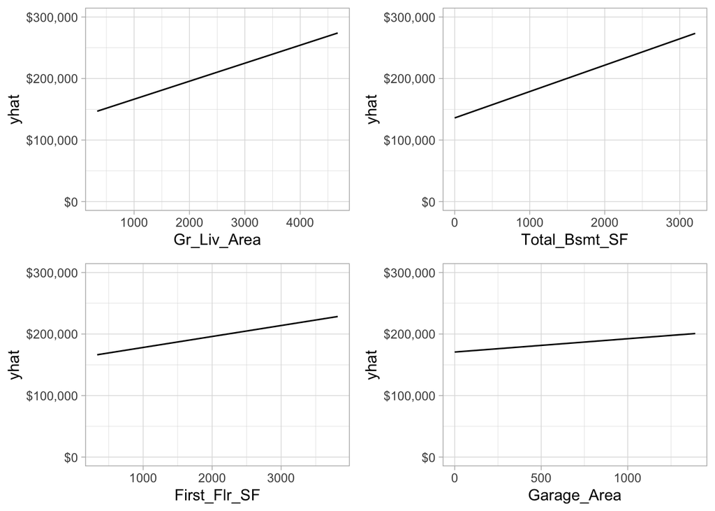

# 2. 지도학습 II: 로지스틱 회귀(logistic regression)

- 정의: 결과변수가 이분척도일 때 사용되는 회귀분석 방법.

## (1) 준비사항

```r
# 모형수립 과정에 사용되는 주요 패키지.
library(tidyverse) # 데이터 조작 및 시각화용.
library(tidymodels) # 데이터 전처리 및 모형 훈련용.
library(caret) # 모형 훈련용.
library(broom) # 분석결과를 tidy 데이터프레임 형식으로 제시.
library(vip) #변수 중요도 해석용.
library(ROCR) # ROC 곡선 시각화용.

# 시범용 데이터셋.
data("attrition")
attrition <- attrition %>% # 직원의 퇴사 여부를 결정짓는 변수들에 대한 정보를 담고 있음.
  mutate_if(is.ordered, factor, ordered = FALSE) # 순서화된 변수는 "요인"으로 변환하기.

# attrition 데이터셋을 훈련용과 검증용으로 나누기.
set.seed(123) # 재현 가능성을 위해 난수 고정.
attrition_split <- initial_split(attrition, prop = 0.7, strata = "Attrition")
attrition_train <- training(attrition_split)
attrition_test <- testing(attrition_split)
```

## (2) 로지스틱 회귀를 사용하는 이유

- 가정: 신용카드 연체 고객 데이터를 바탕으로 현재 납부할 카드 대금 액수가 연체 여부를 예측해줄 수 있는지 알아보고자 함.
- 모형
  - 선형회귀
    - 납부할 대금 액수가 0에 가까울 때 연체확률을 마이너스로 예측함. 납부할 대금 액수가 매우 커진다면 연쳬 확률을 1보다 큰 값으로 예측할 것.
    - 실제 연체 확률은 0-1 사이이므로 비논리적인 예측임.
    - 데이터가 편포이거나 이상치의 수가 늘어날수록 이러한 비일관성은 더욱 높아질 것.
  - 로지스틱 회귀
    - 결과변수가 이분척도일 때 선형모형은 부적합. 따라서 모든 $X$ 값을 0과 1 사이 값으로 출력해주는 함수를 사용하여 결과변수 확률에 대한 모형을 수립해야 함.
    - 공식
      - $p\left(X\right) = \frac{e^{\beta_0 + \beta_1X}}{1 + e^{\beta_0 + \beta_1X}}$
      - $g\left(X\right) = \ln \left[ \frac{p\left(X\right)}{1 - p\left(X\right)} \right] = \beta_0 + \beta_1 X$
      - $p(X)$: 양의 층위(연체 OX 중 연제 O)가 존재할 확률.
      - $p(X)$에 로짓 변환을 적용함으로써 단순 선형회귀모형와 유사한 선형등식이 만들어짐.
      - $X$가 범주변수여도 OK.

**[그림 1] 선형회귀(왼쪽)와 로지스틱 회귀(오른쪽)의 연체 확률 예측 비교**

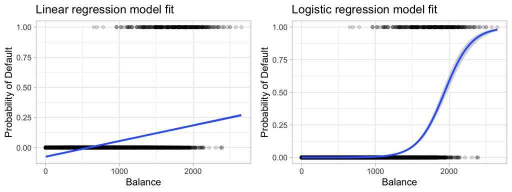

## (3) 단순 로지스틱 회귀(simple logistic regression)

- 함수: R의 내장함수인 `glm`.
  - 논항 1: 예측모형.
  - 논항 2: `family = "binomial"`
  - 논항 3: `data =`

```r
# 직원퇴사 확률 모형 생성하기: 단순 로지스틱 회귀.
model1 <- glm(Attrition ~ MonthlyIncome, family = "binomial", data = attrition_train) # 월급으로 퇴사 확률을 예측.
model2 <- glm(Attrition ~ OverTime, family = "binomial", data = attrition_train) # 초과근무로 퇴사 확률을 예측.
```

**[그림 2] 월급으로 직원퇴사 확률 예측하는 경우(왼쪽)와 초과근무로 직원퇴사 확률을 예측하는 경우(오른쪽) 비교**

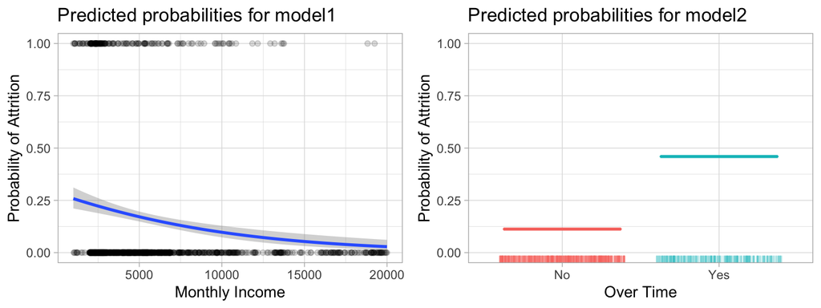

```r
# tidy 형식으로 분석결과 제시하기.
tidy(model1)
```

```
## # A tibble: 2 × 5
##   term           estimate std.error statistic      p.value
##   <chr>             <dbl>     <dbl>     <dbl>        <dbl>
## 1 (Intercept)   -0.886    0.157         -5.64 0.0000000174
## 2 MonthlyIncome -0.000139 0.0000272     -5.10 0.000000344
```

```r
tidy(model2)
```

```
## # A tibble: 2 × 5
##   term        estimate std.error statistic  p.value
##   <chr>          <dbl>     <dbl>     <dbl>    <dbl>
## 1 (Intercept)    -2.13     0.119    -17.9  1.46e-71
## 2 OverTimeYes     1.29     0.176      7.35 2.01e-13
```

```r
# 회귀계수 해석하기.
exp(coef(model1))
```

```
##   (Intercept) MonthlyIncome
##     0.4122647     0.9998614
```

```r
exp(coef(model2))
```

```
## (Intercept) OverTimeYes
##   0.1189759   3.6323389
```

## (4) 다중 로지스틱 회귀

- 여러 개의 예측변수를 사용하여 이분척도 결과변수를 예측할 경우: $p\left(X\right) = \frac{e^{\beta_0 + \beta_1 X + \cdots + \beta_p X_p }}{1 + e^{\beta_0 + \beta_1 X + \cdots + \beta_p X_p}}$
- 모형: 월급(`MonthlyIncome`)과 초과근무(`OverTime`)로 퇴사확률을 예측하는 경우.

```r
# 직원퇴사 확률 모형 생성하기: 다중 로지스틱 회귀.
model3 <- glm(Attrition ~ MonthlyIncome + OverTime, family = "binomial",  data = attrition_train)
tidy(model3)
```

```
## # A tibble: 3 × 5
##   term           estimate std.error statistic  p.value
##   <chr>             <dbl>     <dbl>     <dbl>    <dbl>
## 1 (Intercept)   -1.33     0.177         -7.54 4.74e-14
## 2 MonthlyIncome -0.000147 0.0000280     -5.27 1.38e- 7
## 3 OverTimeYes    1.35     0.180          7.50 6.59e-14
```

**[그림3] 월급과 초과근무로 직원퇴사 확률을 예측하는 경우**

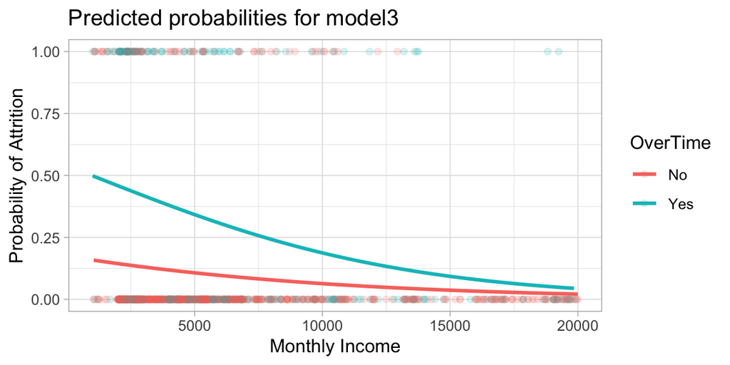

## (5) 모형의 정확도 평가

- 함수: **caret** 패키지의 `train()` 함수
  - 논항 1: `method = "glm"`.
  - 논항 2: `family = "binomial"`.

```r
# 월급(MonthlyIncome)으로 퇴사확률을 예측하는 단순 로지스틱 회귀 모형.
set.seed(123)
cv_model1 <- train(
  Attrition ~ MonthlyIncome,
  data = attrition_train,
  method = "glm",
  family = "binomial",
  trControl = trainControl(method = "cv", number = 10)
)

# 월급(MonthlyIncome)과 초과근무(OverTime)로 퇴사확률을 예측하는 다중 로지스틱 회귀 모형.
set.seed(123)
cv_model2 <- train(
  Attrition ~ MonthlyIncome + OverTime,
  data = attrition_train,
  method = "glm",
  family = "binomial",
  trControl = trainControl(method = "cv", number = 10)
)

# 모든 예측변수로 퇴사확률을 예측하는 다중 로지스틱 회귀 모형.
set.seed(123)
cv_model3 <- train(
  Attrition ~ .,
  data = attrition_train,
  method = "glm",
  family = "binomial",
  trControl = trainControl(method = "cv", number = 10)
)

# 세 모형 간 교차 타당도 비교.
resamples(list(model1 = cv_model1,
               model2 = cv_model2,
               model3 = cv_model3)) %>%
  summary()
```

```
##
## Call:
## summary.resamples(object = .)
##
## Models: model1, model2, model3
## Number of resamples: 10
##
## Accuracy
##             Min.   1st Qu.    Median      Mean   3rd Qu.      Max. NA's
## model1 0.8349515 0.8349515 0.8398379 0.8395076 0.8431373 0.8446602    0
## model2 0.8349515 0.8349515 0.8398379 0.8395076 0.8431373 0.8446602    0
## model3 0.8058252 0.8529412 0.8786765 0.8715662 0.8907767 0.9320388    0
##
## Kappa
##             Min.   1st Qu.    Median      Mean   3rd Qu.    Max. NA's
## model1 0.0000000 0.0000000 0.0000000 0.0000000 0.0000000 0.00000    0
## model2 0.0000000 0.0000000 0.0000000 0.0000000 0.0000000 0.00000    0
## model3 0.2605887 0.3422335 0.4471863 0.4539185 0.5641394 0.70317    0
```

- 오차행렬(confusion matrix): 모형의 수행에 대한 이해를 높이기 위해 오차행렬을 확인할 수 있음. 이를 위해 모형이 예측한 층위(퇴사O vs. 퇴사X)와 훈련 데이터의 실제 결과변수 값을 투입해야 함.

```r
# 모형 3의 예측값 추출하기.
pred_class <- predict(cv_model3, attrition_train)

# 오차행렬 생성하기.
confusionMatrix(data = relevel(pred_class, ref = "Yes"), # pred_class 데이터에서 "Yes"를 준거층위로 변경.
  reference = relevel(attrition_train$Attrition, ref = "Yes")) # attrition_train의 Attrition 데이터에서 "Yes"를 준거층위로 변경.
```

```
## Confusion Matrix and Statistics
##
##           Reference
## Prediction Yes  No
##        Yes  83  20
##        No   82 843
##
##                Accuracy : 0.9008
##                  95% CI : (0.8809, 0.9184)
##     No Information Rate : 0.8395
##     P-Value [Acc > NIR] : 8.982e-09
##
##                   Kappa : 0.5658
##
##  Mcnemar's Test P-Value : 1.542e-09
##
##             Sensitivity : 0.50303
##             Specificity : 0.97683
##          Pos Pred Value : 0.80583
##          Neg Pred Value : 0.91135
##              Prevalence : 0.16051
##          Detection Rate : 0.08074
##    Detection Prevalence : 0.10019
##       Balanced Accuracy : 0.73993
##
##        'Positive' Class : Yes
##
```

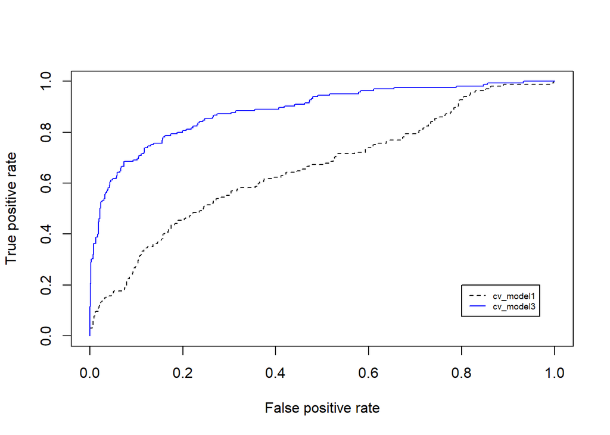

```r
library(ROCR)

# "Yes"에 대한 예측확률 계산하기.
m1_prob <- predict(cv_model1, attrition_train, type = "prob")$Yes
m3_prob <- predict(cv_model3, attrition_train, type = "prob")$Yes

# cv_model1과 cv_model3의 AUC 지표 계산하기.
perf1 <- prediction(m1_prob, attrition_train$Attrition) %>%
  performance(measure = "tpr", x.measure = "fpr") # tpr: True positive rate(TP/P).
perf2 <- prediction(m3_prob, attrition_train$Attrition) %>%
  performance(measure = "tpr", x.measure = "fpr") # fpr: false postive rate(FP/N)

# Plot ROC curves for cv_model1 and cv_model3
plot(perf1, col = "black", lty = 2) # lty = line type.
plot(perf2, add = TRUE, col = "blue") # add = TRUE: 앞선 perf1 플롯에 perf2를 추가함.
legend(0.8, 0.2, legend = c("cv_model1", "cv_model3"), # 0.8, 0.2: 범례 위치.
       col = c("black", "blue"), lty = 2:1, cex = 0.6) # cex = 기호의 크기.
```

- 부분 최소 제곱의 활용
  - 로지스틱 회귀에서도 연속변수의 차원축소가 정확도 향상에 도움을 주는지를 알아보기 위해 부분 최소 제곱을 사용할 수 있음.
  - `attrition` 훈련 데이터: 16개의 등간척도 예측변수 존재.

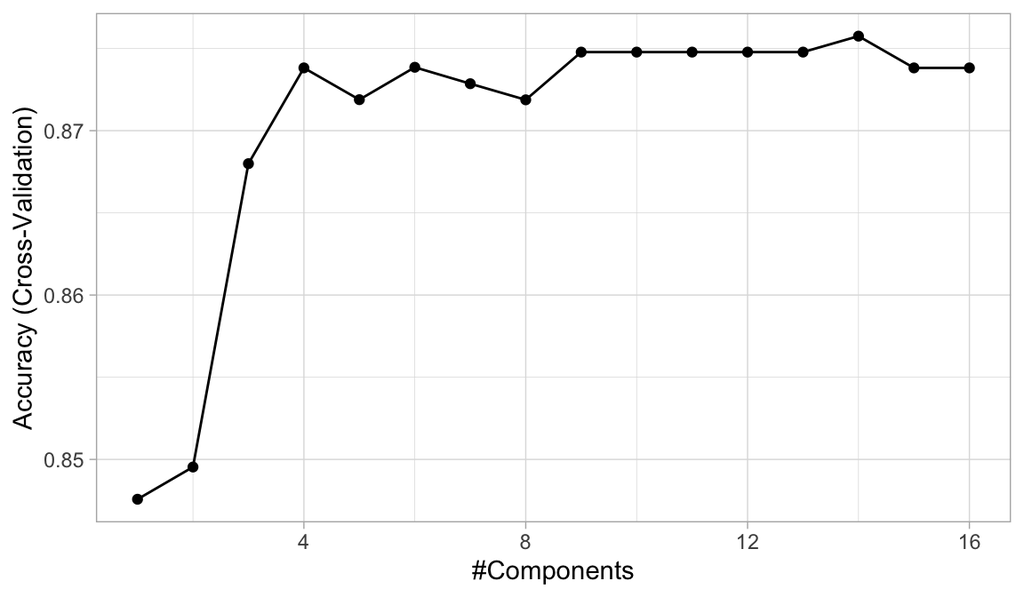

```r
# 부분 최소 제곱 모형 훈련시키기.
set.seed(123)
cv_model_pls <- train(
  Attrition ~ .,
  data = attrition_train,
  method = "pls", # 부분 최소 제곱 적용.
  family = "binomial", # 결과변수는 이분척도.
  trControl = trainControl(method = "cv", number = 10),
  preProcess = c("zv", "center", "scale"),
  tuneLength = 16 # 주성분 개수 범위를 1-16개로 설정.
)

# 가장 낮은 RMSE를 지닌 모형의 주성분 수.
cv_model_pls$bestTune

# 가장 낮은 RMSE를 지닌 모형의 결과값.
cv_model_pls$results %>%
  dplyr::filter(ncomp == pull(cv_model_pls$bestTune)) # ncomp = 주성분의 개수.

# 교차 타당도 확인을 거친 RMSE 시각화하기.
ggplot(cv_model_pls)
```

## (6) 예측변수 해석

- 로지스틱 회귀모형에서 변수의 영향력을 측정하는 방법
  - 모형 매개변수들의 *z*-통계치 절대값 확인. 그러나 상호작용 효과가 포함되거나 복잡한 자료변형이 병행되는 경우 해석이 어려움.
  - **vip** 패키지의 `vip()` 함수 사용.
  - **pdp** 패키지의 `partial()` 함수 사용.

### 1) **vip** 패키지의 `vip()` 함수를 사용하는 경우

- **vip** 패키지의 `vip()` 함수
  - 논항 1: 모형 객체.
  - 논항 2: `num_features` $\Rightarrow$ 중요도 상위 변수의 개수.
  - 논항 3: `method` $\Rightarrow$ 변수의 중요도 유형. 기본값은 `model`임. 모형 기반 변수 중요도 점수 계산 시 사용.

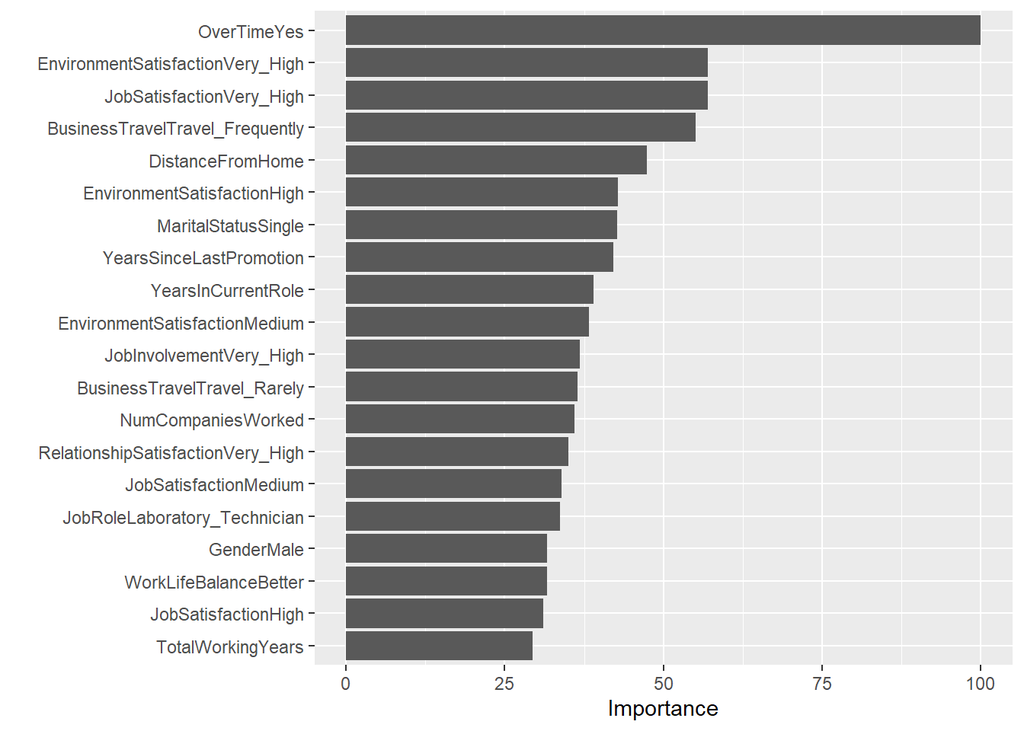

```r
# vip 패키지의 vip() 함수를 사용하여 해당 모형에 속한 상위 20개 변수들의 중요도 계산하기.
vip::vip(cv_model3, num_features = 20, method = "model")
```

### 2) **pdp** 패키지의 `partial()` 함수를 사용하는 경우

```r
# 가장 중요한 네 변수의 부분 독립 플롯.
OverTime.pdp <- partial(cv_model3, "OverTime", plot = TRUE) # 초과근무.
JobSatisfaction.pdp <- partial(cv_model3, "JobSatisfaction", plot = TRUE) # 직업 만족도.
NumCompanaiesWorked.pdp <- partial(cv_model3, "NumCompaniesWorked", plot = TRUE) # 과거에 다닌 회사의 수.
EnvironmentSatisfaction.pdp <- partial(cv_model3, "EnvironmentSatisfaction", plot = TRUE) # 회사환경 만족도.
```

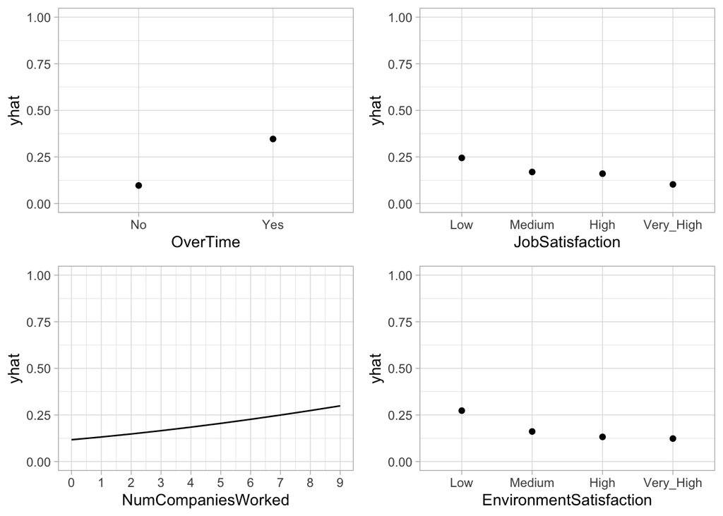

# 3. 지도학습 III: 규제회귀(regularized regression)

- 규제회귀의 필요성
  - 빅데이터의 시대에 예측변수의 수가 늘어날수록 선형모형의 통계적 가정을 충족하기가 어렵게 될 뿐만 아니라, 훈련 데이터에 과적합되는 현상이 발생.
  - **규제(regularization)** 회귀는 추정된 회귀계수를 제약(constrain) 또는 규제(regularize)하는 수단을 제공함으로써 분산과 측정오차를 줄여줄 수 있음.

## (1) 준비사항

```r
# 모형수립 과정에 사용되는 주요 패키지.
library(tidyverse) # 데이터 조작 및 시각화용.
library(tidymodels) # 데이터 전처리 및 모형 훈련용.
library(glmnet) # 규제회귀 수행용.
library(caret) # 모형 훈련용.
library(broom) # 분석결과를 tidy 데이터프레임 형식으로 제시.
library(vip) #변수 중요도 해석용.

# 시범용 데이터셋.
library(AmesHousing)
ames <- AmesHousing::make_ames() %>% # Iowa주 Ames의 2,930개 부동산 물건에 대한 정보를 담고 있음.
  as_tibble()

# ames 데이터셋을 훈련용과 검증용으로 나누기.
set.seed(123) # 재현 가능성을 위해 난수 고정.
split <- initial_split(ames, prop = 0.7)
ames_train <- training(split)
ames_test <- testing(split)
```

## (2) 왜 규제(regularize)인가?

- 최소 제곱법
  - 목적
    - 관찰값과 예측값 간 오차의 제곱합(sum of squared errors, SSE)을 최소화하는 회귀선을 찾는 데 목적이 있음.
    - 아래 [그림 1]의 회색선(관찰값[붉은 점]과 예측값[파란 선] 간 수직거리)을 최소화하는 회귀선을 파악하는 데 목적이 있음.
  - 함수공식: $\text{minimize} \left( SSE = \sum^n_{i=1} \left(y_i - \hat{y}_i\right)^2 \right)$
  - 가정
    - 예측변수와 결과변수가 선형적 관계일 것.
    - 관찰값이 예측변수보다 많을 것($n > p$).
    - 다중공선성이 없을 것.
  - 한계
    - 빅데이터의 시대인 만큼 예측변수가 관찰값을 초과하는 경우($p > n$)가 비일비재. *p*가 증가할수록 최소 제곱법의 가정을 위반할 가능성이 높아짐.
    - 모형의 차원이 높아질수록 과적합의 우려가 큼. 즉 훈련 데이터에만 잘 맞도록 학습되므로 해당 모형을 새로운 데이터에 적용하기 어려워짐.
    - 과적합은 필연적으로 회귀계수의 분산을 높이게 됨([8주차 수업자료: 분산](https://cognitivepsychology.github.io/NLP/week8.html)). 회귀계수의 분산이 커진다는 것은 회귀계수의 값이 매우 커질 수 있음을 의미.

**[그림 1] 최소 제곱법을 사용하여 회귀선 적합화하기**

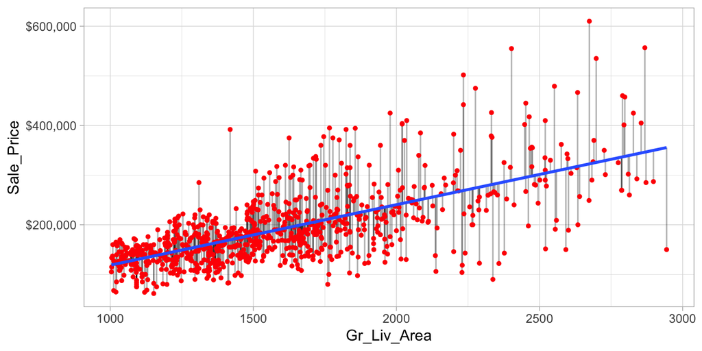

- $p > n$일 때 최소 제곱법 문제 해결책
  - 예측변수의 일부만 추출하는 경우
    - 강한 분기점 변수선택(hard thresholding feature selection)
      - 유형: 전방선택, 후방제거 등.
      - 단점: 계산의 비효율성, 모형에 넣거나 빼거나 둘 중 하나의 선택지밖에 없음.
    - 약한 분기점 변수선택(soft thresholding feature selection)
      - 설명: 불필요한 예측변수의 효과를 0에 가깝게 만들어 해당 변수의 회귀계수를 무력화하는 것.
      - 장점: 좀더 정확한 모형을 수립할 수 있고, 해석하기에도 쉬워짐.
- 규제회귀
  - 설명: 최소 제곱법 회귀의 대안으로, 모든 회귀계수 추정치의 총 크기(total size)를 제약하는 것.
  - 원리
    - 회귀계수의 값이 방대해지는 것을 방지한다면 회귀계수의 분산이 작아지므로 과적합을 방지할 수 있음.
    - 정보성이 떨어지는(설명력이 부족한) 예측변수에 대한 회귀계수의 크기를 효과적으로 제약한다면 변수선정을 통해 차원을 축소한 것과 같은 효과를 얻을 수 있음. $\Rightarrow$ 그 결과 과적합 또한 방지할 수 있음.
  - 회귀계수의 크기와 변동을 감소시키는 데 도움이 됨. $\Rightarrow$ 모형의 분산이 감소됨. $\Rightarrow$ 단, 분산이 감소되는 대신 편향의 증가를 감수해야 함.
  - **페널티** 모형(penalized models) 또는 **축소** 모형(shrinkage models)으로도 불림.
  - 함수공식
    - $\text{minimize} \left( SSE + P \right)$ $\Rightarrow$ $P$는 페널티항(penalty term)에 해당.
    - 페널티 매개변수(penalty parameters): 회귀계수의 크기를 제약함으로써 모형의 과적합을 방지하도록 설정. 따라서 회귀계수를 증가시킬 수 있는 유일한 방법은 손실함수([EX] 오차의 제곱합[SSE])를 줄이는 수밖에 없음.
  - 페널티 매개변수의 유형
    - 리지(ridge) 회귀.
    - 라소(least absolute shrinkage and selection operator, lasso/LASSO) 회귀.
    - 엘라스틱넷 회귀(elastic net, ENET): 리지와 라소의 조합.

### 1) 리지 회귀

- 함수공식
  - $\text{minimize } \left( SSE + \lambda \sum^p_{j=1} \beta_j^2 \right)$.
  - 페널티의 크기
    - $L^2$로 지칭. 광범위한 값을 취할 수 있으며, 초매개변수 $\lambda$에 의해 조절됨.
    - $\lambda=0$: 보통의 최소 제곱법 회귀와 동일. 오차 제곱합만 최소화하면 됨.
    - $\lambda \rightarrow \infty$: 페널티가 커지면서 회귀계수(β)를 0에 가깝도록 만듦.

**[그림 2] $\lambda$ 증가($0 $\rightarrow$ $)에 따른 15개 예측변수의 리지 회귀 계수 변화**

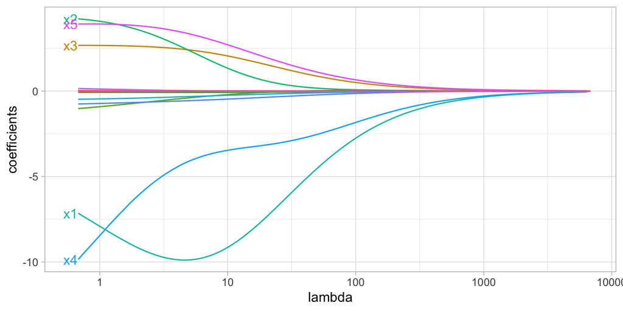

- [그림 2] 해석
  - 분석 전에 회귀계수가 정규화되었음에도 일부 예측변수는 $\lambda$가 0에 가까웠을 때 상당한 큰 값을 보임.
  - `x1` 예측변수는 큰 음의 매개변수를 나타내며, $\lambda \approx 7$까지 심하게 요동치다가 지속적으로 0으로 수렴. $\Rightarrow$ 이는 다중공선성의 징후이며, $\lambda > 7$로 회귀계수를 제약하는 것이 분산과 예측오차를 줄이는 데 도움이 될 것.
- 리지 회귀의 장점
  - $\lambda$의 조절을 통해 상관을 지닌 많은 예측변수들을 한데 수렴하도록 해줌.
  - 정보성이 떨어지는 덜 중요한 예측변수의 회귀계수를 0에 가깝게 만들어줌. $\Rightarrow$ 우리 데이터의 중요한 신호들을 분명하게 파악하는 데 도움을 줌.
- 리지 회귀의 단점
  - 실제로 예측변수 선정을 수행해주는 것은 아니며, 최종모형에 모든 예측변수를 다 포함하게 됨.
  - 내 모형에 모든 예측변수가 들어 있되 덜 중요한 변수들이 야기할 수 있는 잡음을 줄이고자 한다면 좋은 선택지임([EX] 심각한 다중공선성을 지닌 소규모 데이터셋인 경우.
  - 분석결과를 좀더 쉽게 해석하고자 한다면, 그리고 쓸모없는 잉여 예측변수를 다 지니고 있을 필요가 없다면 라소나 엘라스틱넷을 사용하는 편이 나음.

### 2) 라소 회귀

- 함수공식
  - $\text{minimize } \left( SSE + \lambda \sum^p_{j=1} | \beta_j | \right)$.
  - 리지 회귀의 $L^2$ 대신 $L^1$이 투입.
- 리지 회귀와의 차이점
  - 리지 회귀는 예측변수를 0에 근접할 때까지 축소하지만, 라소 회귀는 실제로 0이 될 떄까지 축소.
  - 실제로 자동화된 예측변수 선정의 효과도 누릴 수 있음.

**[그림 3] $\lambda$ 증가($0 $\rightarrow$ $)에 따른 15개 예측변수의 라소 회귀 계수 변화**

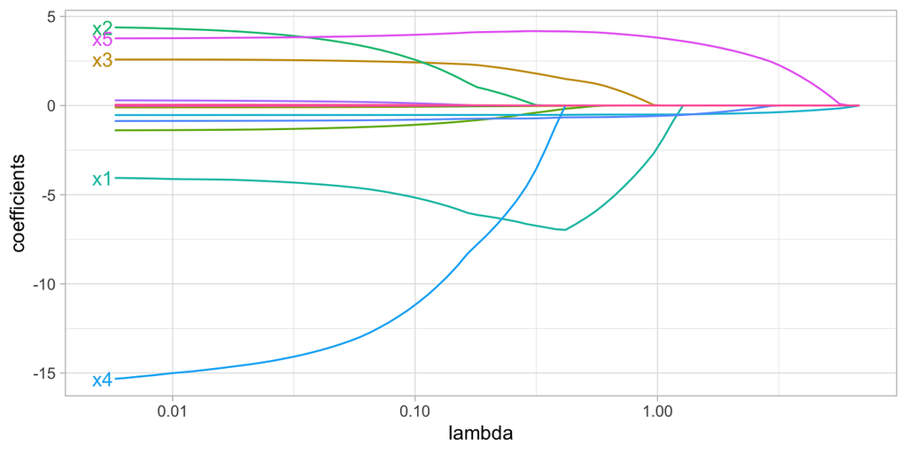

- [그림 3] 해석
  - $\lambda < 0.01$일 때까지는 15개 예측변수 모두 모형에 포함됨.
  - $\lambda \approx 0.5$가 되면서 9개의 예측변수만 남음.
  - $log\left(\lambda\right) = 1$가 되면서 5개의 예측변수만 남음.
  - 데이터셋의 예측변수가 많다면 라소는 가장 크고 선명한 신호를 지닌 예측변수만 선정하는 용도로 사용 가능.

### 3) 엘라스틱넷 회귀

- 함수공식
  - $\text{minimize } \left( SSE + \lambda_1 \sum^p_{j=1} \beta_j^2 + \lambda_2 \sum^p_{j=1} | \beta_j | \right)$.
  - 리지 회귀와 라소 회귀의 페널티를 함께 투입.
- 라소/리지 회귀와의 차이점
  - 라소 회귀: 예측변수 선정을 수행해줌. 그러나 강한 상관을 지닌 두 변수의 회귀계수를 축소시킬 때 한 변수는 0으로 만들 수 있지만, 다른 변수는 모형에 남아 있게 됨. 그러나 그 변수선정 과정은 데이터 의존적이며 비체계적임.
  - 리지 회귀: 상관을 지닌 변수들을 함께 체계적으로 처리하는 데 좀 더 효과적.
- 엘라스틱넷의 장점: 리지 페널티를 통해 효과적인 규제라는 장점을 & 라소 페널티를 통해 예측변수 선정이라는 장점을 함께 누릴 수 있음.

**[그림 4] $\lambda$ 증가(0 $\rightarrow$ )에 따른 15개 예측변수의 엘라스틱넷 회귀 계수 변화**

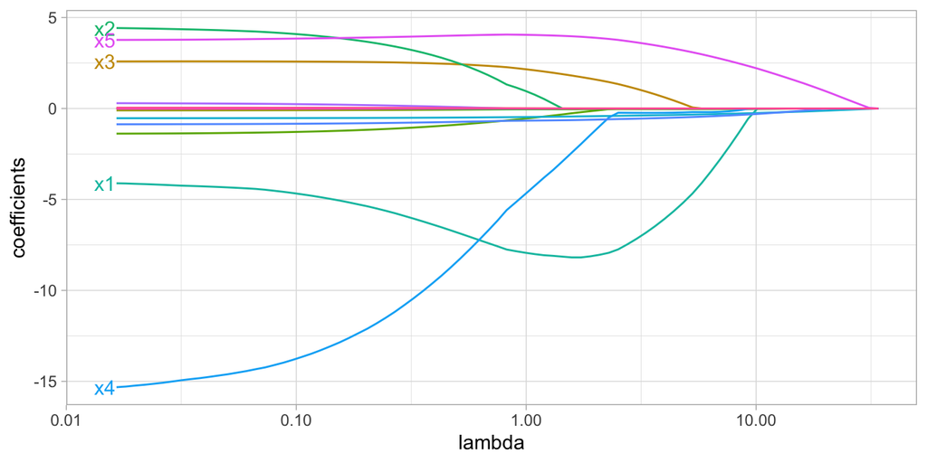

## (3) 실행

### 1) **glmnet** 패키지로 직접 실행하기

- 초매개변수 $\lambda$
  - 우리의 모형이 훈련 데이터에 과적합되는 것을 방지하는 데 도움을 주는 초매개변수.
  - **glmnet** 패키지는 데이터를 바탕으로 적절한 $\lambda$ 값을 자동으로 생성해줌.
  - 그러나 최적의 $\lambda$를 구하려면 *k*-겹 CV를 실시하는 것이 가장 합리적.
- 함수: **glmnet** 패키지의 `cv.glmnet()` 함수
  - 논항 1: `x` $\Rightarrow$ 예측변수 데이터프레임.
  - 논항 2: `y` $\Rightarrow$ 결과변수 벡터.
  - 논항 3: `alpha` $\Rightarrow$ 리지(`alpha = 0`), 라소(`alpha = 1`), 엘라스틱넷(0 < `alpha` < 1).
  - 논항 4: `lambda` $\Rightarrow$ 직접 시험해볼 람다 값 범위.
  - 논항 5: `nfolds` $\Rightarrow$ CV의 겹 수.
- 주의사항
  - *k*-겹의 기본값은 10겹임. 따라서 `nfolds`를 지정하지 않으면 자동으로 `nfolds = 10`으로 실행행.
  - **glmnet** 패키지 함수에는 **tidymodels** 패키지의 전처리 청사진을 투입할 수 없음.

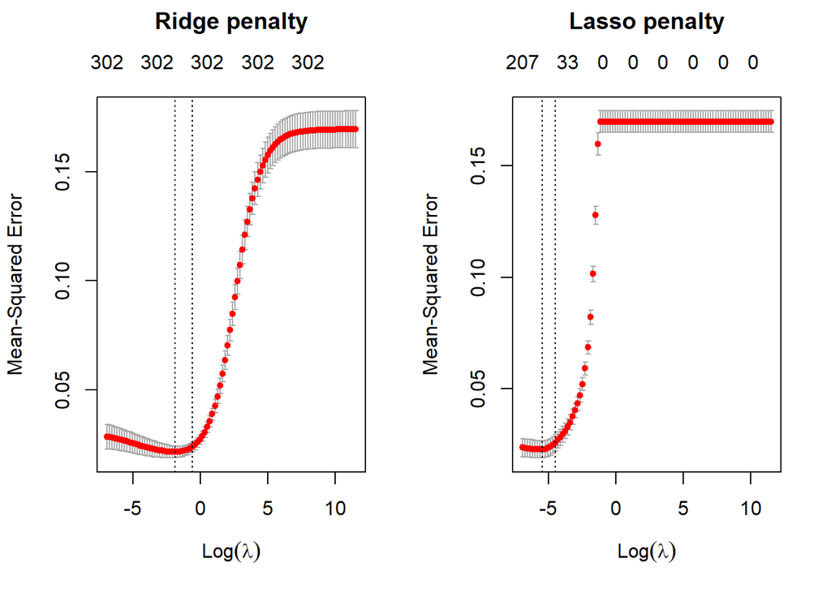

```r
# model.matrix() 함수를 사용하여 명목척도 예측변수들에 대해 더미 인코딩 시행.
X <- model.matrix(Sale_Price ~ ., ames_train)[, -1] # 절편(intercept)이 1열에 있으므로 제거.

# 결과변수는 로그 변환 시행.
Y <- log(ames_train$Sale_Price)

# 직접 시험해볼 람다 값 범위 입력하기.
my_lambdas <- 10^seq(-3, 5, length.out = 100)

# CV 리지 회귀 시행.
ridge <- cv.glmnet(
  x = X,
  y = Y,
  alpha = 0,
  lambda = my_lambdas,
  nfolds = 10)

# CV 라소 회귀 시행.
lasso <- cv.glmnet(
  x = X,
  y = Y,
  alpha = 1,
  lambda = my_lambdas,
  nfolds = 10)

# 결과 시각화하기.
par(mfrow = c(1, 2)) # 두 플롯을 나란히 배치하기.
plot(ridge, main = "Ridge penalty\n\n") # 리지 모형 시각화.
plot(lasso, main = "Lasso penalty\n\n") # 라소 모형 시각화.
```

```r
# 리지 모형.

min(ridge$cvm)  # 최소 MSE.
```

```
## [1] 0.02144769
```

```r
ridge$lambda.min # 최소 MSE에 대한 람다 값.
```

```
## [1] 0.1519911
```

```r
ridge$cvm[ridge$lambda == ridge$lambda.1se] # 최소 MSE + 1표준오차 범위 계산.
```

```
## [1] 0.02376127
```

```r
ridge$lambda.1se # 최소 MSE + 1표준오차에 대한 람다 값.
```

```
## [1] 0.559081
```

```r
# 라소 모형.

min(lasso$cvm) # 최소 MSE.
```

```
## [1] 0.02295127
```

```r
lasso$lambda.min # 최소 MSE에 대한 람다 값.
```

```
## [1] 0.004430621
```

```r
lasso$nzero[lasso$lambda == lasso$lambda.min] # 최소 MSE일 때 회귀계수의 수.
```

```
## s91
## 122
```

```r
lasso$cvm[lasso$lambda == lasso$lambda.1se] # 최소 MSE + 1표준오차 범위 계산.
```

```
## [1] 0.02586652
```

```r
lasso$lambda.1se # 상기 MSE에 대한 람다 값.
```

```
## [1] 0.01123324
```

```r
lasso$nzero[lasso$lambda == lasso$lambda.1se] # 최소 MSE + 1표준오차일 때 회귀계수의 수.
```

```
## s86
##  72
```

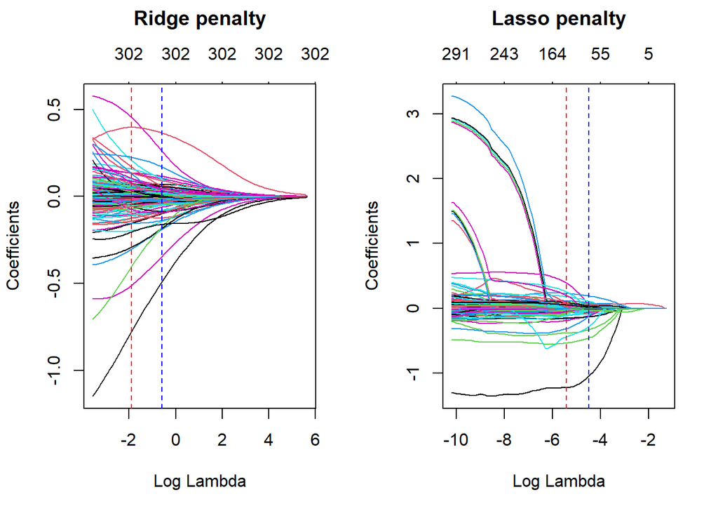

```r
# 리지 모형.
ridge_min <- glmnet(
  x = X,
  y = Y,
  alpha = 0)

# 라소 모형.
lasso_min <- glmnet(
  x = X,
  y = Y,
  alpha = 1)

# 두 플롯 나란히 배치하기.
par(mfrow = c(1, 2))

# 리지 모형 결과 시각화하기.
plot(ridge_min, xvar = "lambda", main = "Ridge penalty\n\n") # xvar: x축 변수(람다 값).
abline(v = log(ridge$lambda.min), col = "red", lty = "dashed") # MSE가 최소인 로그 변환 람다에 수직선 긋기.
abline(v = log(ridge$lambda.1se), col = "blue", lty = "dashed") # 최소 MSE + 1표준편차인 로그 변환 람다에 수직선 긋기.

# 라소 모형 결과 시각화하기.
plot(lasso_min, xvar = "lambda", main = "Lasso penalty\n\n") # xvar: x축 변수(람다 값).
abline(v = log(lasso$lambda.min), col = "red", lty = "dashed") # MSE가 최소인 로그 변환 람다에 수직선 긋기.
abline(v = log(lasso$lambda.1se), col = "blue", lty = "dashed") # 최소 MSE + 1표준편차인 로그 변환 람다에 수직선 긋기.
```

### 2) **caret** 패키지로 실행하기

```r
# 재표집 및 완전탐색 전략 수립.
fit_control <- trainControl(method = "cv",
                            number = 10,
                            search = "random")

# tidymodels 패키지를 사용하여 전처리 청사진 수립하기.
blueprint <- recipe(Sale_Price ~ ., data = ames_train) %>%
  step_log(all_outcomes()) %>%
  step_dummy(all_nominal_predictors()) %>%
  step_zv(all_predictors()) %>%
  step_nzv(all_predictors()) %>%
  step_normalize(all_numeric_predictors())

# caret 패키지를 사용하여 규제모형(엘라스틱넷 회귀) 훈련시키기.
set.seed(123)
cv_glmnet <- train(
  blueprint,
  data = ames_train,
  method = "glmnet",
  trControl = fit_control,
  tuneLength = 10
)

# RMSE가 가장 낮은 모형 파악하기.
cv_glmnet$bestTune
```

```
##       alpha      lambda
## 9 0.9404673 0.002468792
```

```r
# RMSE가 가장 낮은 모형 결과 제시하기.
cv_glmnet$results %>%
  filter(alpha == cv_glmnet$bestTune$alpha, lambda == cv_glmnet$bestTune$lambda)
```

```
##       alpha      lambda      RMSE  Rsquared       MAE     RMSESD RsquaredSD
## 1 0.9404673 0.002468792 0.1590929 0.8516494 0.1020923 0.05001723 0.09113454
##         MAESD
## 1 0.009882927
```

- **caret** 패키지를 사용하여 전처리하는 경우:

```r
# 재표집 및 완전탐색 전략 수립.
fit_control <- trainControl(method = "cv",
                            number = 10,
                            search = "random")

# caret 패키지를 사용하여 규제모형(엘라스틱넷 회귀) 훈련시키기.
set.seed(123)
cv_glmnet.1 <- train(
  x = X,
  y = Y,
  method = "glmnet",
  trControl = fit_control,
  tuneLength = 10
)
# RMSE가 가장 낮은 모형 파악하기.
cv_glmnet.1$bestTune
```

```
##       alpha      lambda
## 9 0.9404673 0.002468792
```

```r
# RMSE가 가장 낮은 모형 결과 제시하기.
cv_glmnet.1$results %>%
  filter(alpha == cv_glmnet.1$bestTune$alpha, lambda == cv_glmnet.1$bestTune$lambda)
```

```
##       alpha      lambda      RMSE Rsquared       MAE   RMSESD RsquaredSD
## 1 0.9404673 0.002468792 0.1451521 0.874459 0.0854236 0.050363 0.08505932
##         MAESD
## 1 0.008409516
```

[figure not shown]

```r
# CV 규제모형의 RMSE 시각화하기.
cv_glmnet.1.p <- ggplot(cv_glmnet.1)
```

## (4) 예측변수 해석

- 해석방법
  - 규제회귀 변수의 중요도 또한 선형회귀와 유사하게 해석.
  - 변수의 중요도는 표준화 계수의 크기에 의해 결정됨.
  - 부분 최소 제곱(PLS) 모형과 대체로 유사한 변수들이 상위 20개 변수로 선정되었으나, 그 순위는 다름.

### 1) **vip** 패키지의 `vip()` 함수를 사용하는 경우

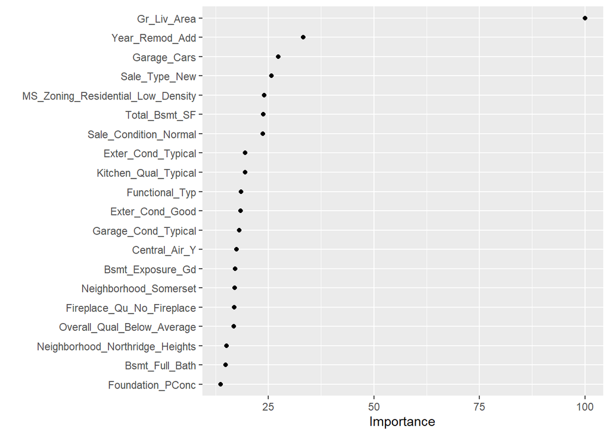

```r
# vip 패키지의 vip() 함수를 사용하여 해당 모형에 속한 상위 20개 변수들의 중요도 계산하기.
vip::vip(cv_glmnet, num_features = 20, geom = "point")
```

### 2) **pdp** 패키지의 `partial()` 함수를 사용하는 경우

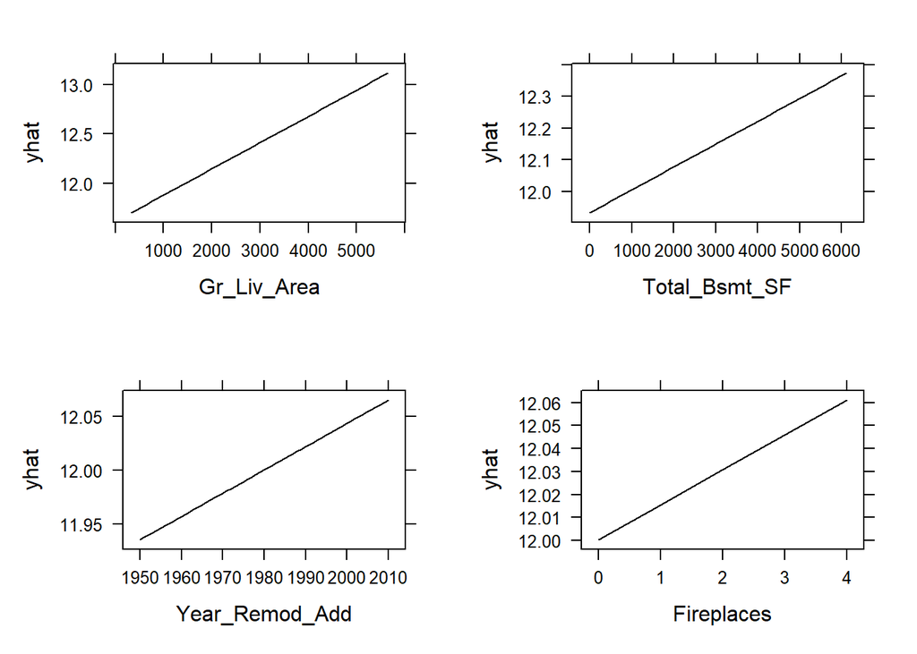

```r
# 가장 중요한 네 변수의 부분 독립 플롯(y축이 로그 변환된 주택가격임).
Gr_Liv_Area.pdp <- partial(cv_glmnet, "Gr_Liv_Area", plot = TRUE) # 지하공간을 제외한 생활공간의 제곱피트.
Total_Bsmt_SF.pdp <- partial(cv_glmnet, "Total_Bsmt_SF", plot = TRUE) # 지하공간의 총 제곱피트.
Year_Remod_Add.pdp <- partial(cv_glmnet, "Year_Remod_Add", plot = TRUE) # 주택의 리모델링 시기.
Fireplaces.pdp <- partial(cv_glmnet, "Fireplaces", plot = TRUE) # 벽난로의 수.

library(gridExtra)
grid.arrange(Gr_Liv_Area.pdp, Total_Bsmt_SF.pdp, Year_Remod_Add.pdp, Fireplaces.pdp, nrow = 2)
```

## (5) 결과변수가 이분척도인 데이터

```r
# 로지스틱 회귀 모형 훈련시키기.
set.seed(123)
glm_mod <- train(
  Attrition ~ .,
  data = attrition_train,
  method = "glm",
  family = "binomial",
  preProcess = c("zv", "center", "scale"),
  trControl = trainControl(method = "cv", number = 10))

# 규제 로지스틱 회귀 모형 훈련시키기.
set.seed(123)
regularized_mod <- train(
  Attrition ~ .,
  data = attrition_train,
  method = "glmnet",
  family = "binomial", # 결과변수가 이분척도일 때 family = "binomial" 추가해주기!
  preProc = c("zv", "center", "scale"),
  trControl = trainControl(method = "cv", number = 10, search = "random"),
  tuneLength = 10) # 무선탐색(alpha 10개 * lambda 10개 = 총 100개 조합)으로 최적의 alpha와 lambda 값 찾아내기.

# 두 모형 간 교차 타당도 비교.
resamples(list(model1 = glm_mod,
               model2 = regularized_mod)) %>%
  summary()
```

```
##
## Call:
## summary.resamples(object = .)
##
## Models: model1, model2
## Number of resamples: 10
##
## Accuracy
##             Min.   1st Qu.    Median      Mean   3rd Qu.      Max. NA's
## model1 0.8058252 0.8529412 0.8786765 0.8715662 0.8907767 0.9320388    0
## model2 0.8349515 0.8671757 0.8823529 0.8813319 0.9053398 0.9223301    0
##
## Kappa
##             Min.   1st Qu.    Median      Mean   3rd Qu.      Max. NA's
## model1 0.2605887 0.3422335 0.4471863 0.4539185 0.5641394 0.7031700    0
## model2 0.1912240 0.2806719 0.4225573 0.4157392 0.5597942 0.6281588    0
```